# Week 7 Lab

(enter your name)

2/21 or 2/22

```r
pacman::p_load(tidyverse, modelsummary, margins)
```

## DIBELS dataset

In this lab, we’ll be using [the DIBELS dataset](https://daviddliebowitz.github.io/EDUC643_23W/data/dibels.csv) to check our understanding of multiple regression (ML), where outcome variable is continuous and predictor of research interest is continuous or categorical.

Read the [DIBELS codebook](https://daviddliebowitz.github.io/EDUC643_23W/data/dibels_codebook.pdf) and print the structure of the dataset to really understand the variables and the levels/values of each variable.

```r
df0 <- read.csv("https://daviddliebowitz.github.io/EDUC643_23W/data/dibels.csv")
# str(df0)
```

### Data management

#### The outcome variable

Our outcome variable of interest is school-by-grade-by-wave ORF score - I know this is confusing, carefully read below information, you’ll understand more about this variable:

- ORF score was collected four times, begin of the year 2019-20 (or fall 2019), middle of the year 2019-20 (or winter 2020), begin of the year 2020-21 (or fall 2020), and middle of the year 2020-21 (or winter 2021)
  - for the sake of simplicity, we name them four waves and denote them as w1, w2, w3, and w4
  - a side note here is that we consider w1 and w2 pre-pandemic and w3 and w4 post-pandemic

```r
df1 <- df0 %>%
  select(id = sch_deid,
         grade,
         w1 = y1_boy_mean,
         w2 = y1_moy_mean,
         w3 = y2_boy_mean,
         w4 = y2_moy_mean,
         enrollment = school_enroll,
         frpl = frpl_prop,
         asian = asian_prop,
         black = black_prop,
         hisp = hisp_prop,
         white = white_prop)
# str(df1)
```

- ORF score was collected at five grade-levels, grades 1-5 in each school, which means the data is school-by-grade level
- But we would like this variable to be school-by-grade-by-wave level
  - in other words, we would like to directly see our outcome variable to be the ORF score for a certain school, at a certain grade level, in a certain wave
  - the original dataset does not have this variable, instead, it has four variables that store the ORF score of four waves, which means the data is in “wide” format ([check here to learn more](https://tavareshugo.github.io/r-intro-tidyverse-gapminder/09-reshaping/index.html) about “wide” vs “long” format dataset and how to use the pivot functions to reshape your data)
- There’re multiple ways to turn this wide format dataset to long format, here we introduce two options
  - First, intuitively, we can create a dataset for each wave and use rbind() function to combine four datasets
  - However, this operation is computationally expensive (imagine computing multiple variables this way). In the future, you may want to learn to use pivot_longer()

```r
df1_w1 <- df1 %>%
  select(-c(w2, w3, w4),
         score = w1) %>%
  mutate(wave = 1)

df1_w2 <- df1 %>%
  select(-c(w1, w3, w4),
         score = w2) %>%
  mutate(wave = 2)

df1_w3 <- df1 %>%
  select(-c(w2, w1, w4),
         score = w3) %>%
  mutate(wave = 3)

df1_w4 <- df1 %>%
  select(-c(w2, w3, w1),
         score = w4) %>%
  mutate(wave = 4)

df2 <- rbind(df1_w1, df1_w2, df1_w3, df1_w4)

# str(df2)
```

```r
df3 <- pivot_longer(df1,
                   cols = w1:w4,
                   names_to = "wave",
                   names_prefix = "w",
                   values_to = "score")

# str(df3)
```

### More datamanagement

- Create a dichotomous variable, post, coded one if the score was collected post-pandemic (waves 3 and 4) and zero otherwise (waves 1 and 2)
- Check for the types of variables and convert to the right types if needed; e.g., grade should be a categorical variable
- Check and deal with missingness

```r
df <- df3 %>%
  mutate(post = as.factor(ifelse(wave %in% c(3, 4), 1, 0)),
         id = as.character(id),
         grade = as.factor(grade),
         enrollment = as.numeric(enrollment))
# str(df)
```

### The summary statistics of our analytic sample

Summarize continuous variables:

```r
df %>%
  datasummary_skim()
```

Unique (#)

Missing (%)

Mean

SD

Min

Median

Max

enrollment

593

0

337.3

169.9

25.0

326.0

1014.0

[figure not shown]

frpl

1856

0

1.1

0.9

0.0

1.1

17.8

[figure not shown]

asian

2941

0

0.1

0.1

0.0

0.1

1.0

[figure not shown]

black

2687

0

0.2

0.3

0.0

0.1

1.0

[figure not shown]

hisp

2704

0

0.4

0.4

0.0

0.4

1.0

[figure not shown]

white

2708

0

0.4

0.3

0.0

0.4

1.0

[figure not shown]

score

19469

0

72.9

38.1

0.0

74.4

204.0

[figure not shown]

Summarize categorical variables:

```r
df %>%
  datasummary_skim(type = "categorical")
```

|  |  | N | % |
| --- | --- | --- | --- |
| grade | 1 | 5736 | 26.6 |
|  | 2 | 5448 | 25.2 |
|  | 3 | 4024 | 18.6 |
|  | 4 | 3324 | 15.4 |
|  | 5 | 3052 | 14.1 |
| wave | 1 | 5396 | 25.0 |
|  | 2 | 5396 | 25.0 |
|  | 3 | 5396 | 25.0 |
|  | 4 | 5396 | 25.0 |
| post | 0 | 10792 | 50.0 |
|  | 1 | 10792 | 50.0 |

## Research question 1: is there a relationship between score and enrollment?

Here, y = score, x = enrollment

Null: there is no relationship between score and test enrollment, on average in the population.

Estimation equation:
$$SCORE = \beta_0 +
\beta_1 * ENROLLMENT + \epsilon$$

Visualization:

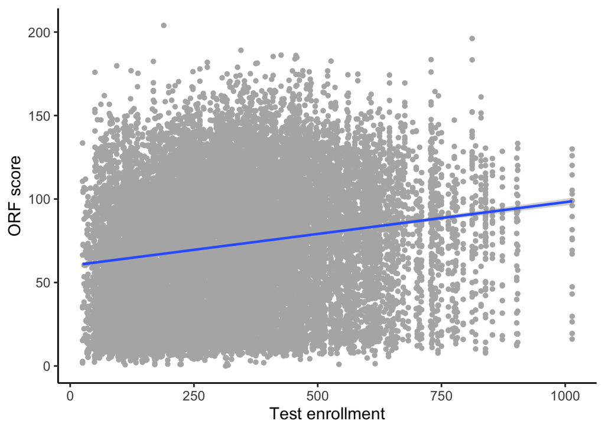

```r
df %>%
  ggplot(aes(y = score, x = enrollment)) +
  geom_point(color = "grey70") +
  geom_smooth(method = "lm") +
  labs(x = "Test enrollment",
       y = "ORF score") +
  theme_classic(base_size = 14)
```

OLS results:

```r
m1 <- lm(score ~ enrollment, df)

modelsummary(m1,
             stars = TRUE,
             gof_omit = "Adj.|Log.Lik.|AIC|BIC")
```

|  | Model 1 |
| --- | --- |
| (Intercept) | 60.056*** |
|  | (0.569) |
| enrollment | 0.038*** |
|  | (0.002) |
| Num.Obs. | 21584 |
| R2 | 0.029 |
| F | 638.837 |
| RMSE | 37.59 |

+ p < 0.1, * p < 0.05, ** p < 0.01, *** p < 0.001

## Research question 2: does score differ pre- and post-pandemic?

Here, y = score, x = post

Null: the score was equal before and after pandemic, on average in the population.

Estimation equation:
$$SCORE = \beta_0 +
\beta_1 * POST + \epsilon$$

Visualization:

Our goal here is to visualize how the outcome variable score differs across different levels of the categorical variable post (same as to research questions 3 and 4 down below). Note that you have multiple options, such as geom_jitter, geom_boxplot, geom_density, or geom_violin. Choose your own adventure.

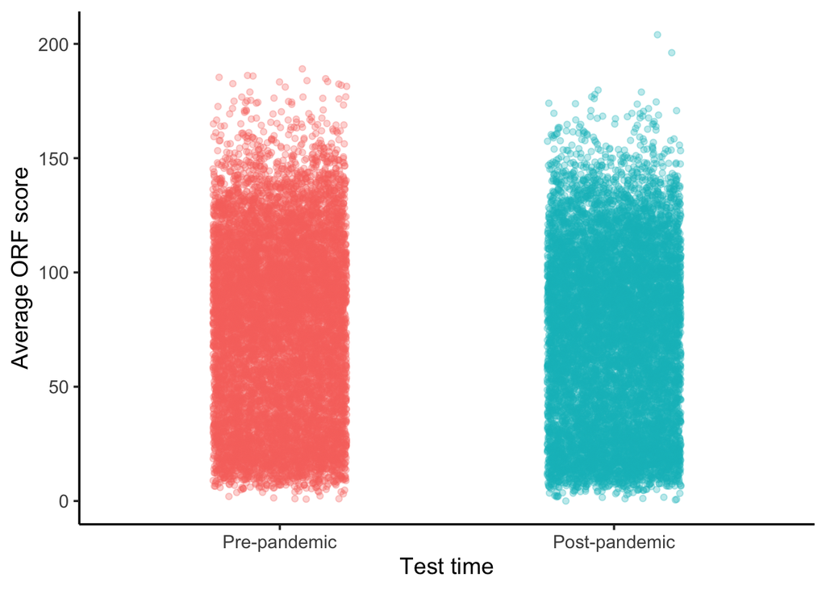

```r
df %>%
  mutate(post = factor(post, levels = c(0, 1), labels = c("Pre-pandemic", "Post-pandemic"))) %>%
  ggplot(aes(y = score, x = post, color = post)) +
  geom_jitter(width = 0.2, alpha = 0.3) +
  labs(x = "Test time",
       y = "Average ORF score") +
  theme_classic(base_size = 14) +
  theme(legend.position = "")
```

OLS results:

```r
m2 <- lm(score ~ post, df)

modelsummary(m2,
             stars = TRUE,
             gof_omit = "Adj.|Log.Lik.|AIC|BIC")
```

|  | Model 1 |
| --- | --- |
| (Intercept) | 75.125*** |
|  | (0.367) |
| post1 | −4.450*** |
|  | (0.518) |
| Num.Obs. | 21584 |
| R2 | 0.003 |
| F | 73.686 |
| RMSE | 38.08 |

+ p < 0.1, * p < 0.05, ** p < 0.01, *** p < 0.001

## Research question 3: does score differ across four waves?

Here, y = score, x = wave

Null: the score was equal across four waves, on average in the population.

Here we pick wave 1 as reference level.

Estimation equation:
$$SCORE = \beta_0 +
\beta_1 * WAVE2 + \beta_2 * WAVE3 + \beta_3 * WAVE4 + \epsilon$$

Visualization:

Another option, using geom_boxplot()

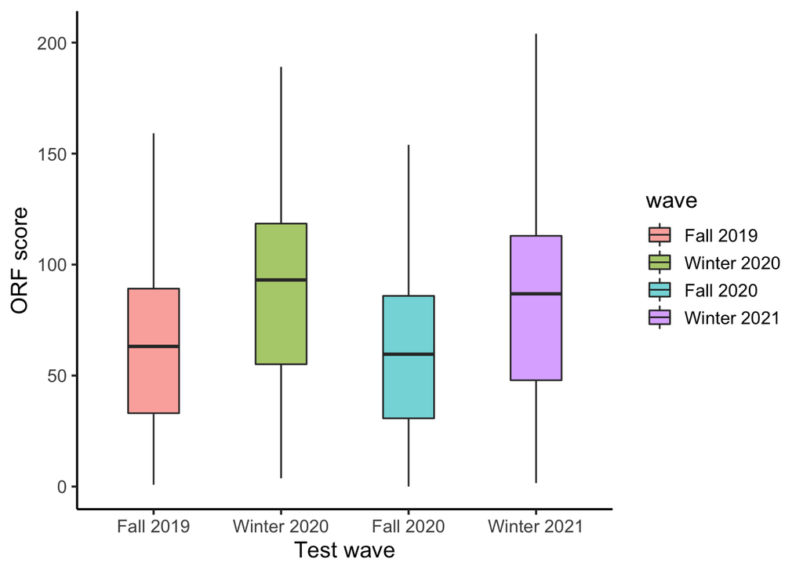

```r
df %>%
  mutate(wave = factor(wave, levels = c(1, 2, 3, 4), labels = c("Fall 2019", "Winter 2020", "Fall 2020", "Winter 2021"))) %>%
  ggplot(aes(y = score, x = wave, fill = wave)) +
  geom_boxplot(width = 0.4, alpha = 0.6) +
  labs(x = "Test wave",
       y = "ORF score") +
  theme_classic(base_size = 14)
```

OLS results:

```r
m3 <- lm(score ~ factor(wave), df)

modelsummary(m3,
             stars = TRUE,
             gof_omit = "Adj.|Log.Lik.|AIC|BIC")
```

|  | Model 1 |
| --- | --- |
| (Intercept) | 62.344*** |
|  | (0.492) |
| factor(wave)2 | 25.562*** |
|  | (0.696) |
| factor(wave)3 | −2.791*** |
|  | (0.696) |
| factor(wave)4 | 19.454*** |
|  | (0.696) |
| Num.Obs. | 21584 |
| R2 | 0.102 |
| F | 817.703 |
| RMSE | 36.14 |

+ p < 0.1, * p < 0.05, ** p < 0.01, *** p < 0.001

ANOVA test results:

```r
anova(m3)
```

```
## Analysis of Variance Table
##
## Response: score
##                 Df   Sum Sq Mean Sq F value    Pr(>F)
## factor(wave)     3  3204894 1068298   817.7 < 2.2e-16 ***
## Residuals    21580 28193461    1306
## ---
## Signif. codes:  0 '***' 0.001 '**' 0.01 '*' 0.05 '.' 0.1 ' ' 1
```

Review [the lecture slides](https://daviddliebowitz.github.io/EDUC643_23W/slides/EDUC643_10_categorical.html#100) to accurately interpret your ANOVA test results.

## Research question 4: does score differ across grade levels?

Here, y = score, x = grade

Null: the score was equal across five grade levels, on average in the population.

Here we pick grade 1 as reference level.

Estimation equation:
$$SCORE = \beta_0 +
\beta_1 * GRADE2 + \beta_2 * GRADE3 + \beta_3 * GRADE4 + \beta_4 *
GRADE5 + \epsilon$$

Visualization:

A third option, using geom_violin()

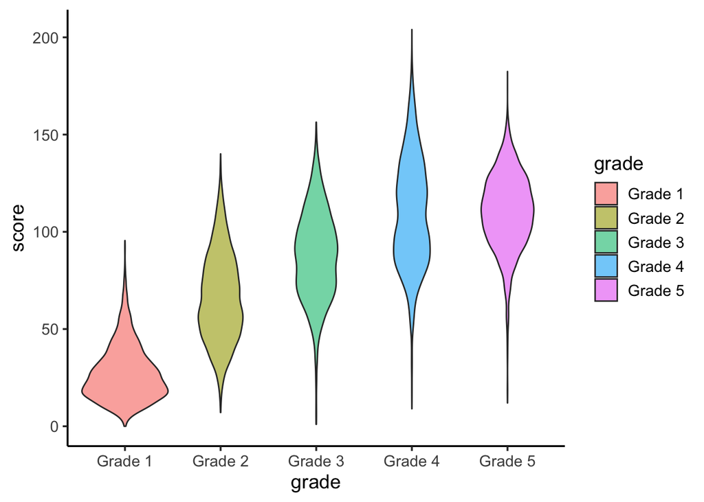

```r
df %>%
  mutate(grade = factor(grade, levels = c(1, 2, 3, 4, 5), labels = c("Grade 1", "Grade 2", "Grade 3", "Grade 4", "Grade 5"))) %>%
  ggplot(aes(y = score, x = grade)) +
  geom_violin(aes(fill = grade), alpha = 0.6) +
  theme_classic(base_size = 14)
```

OLS results:

```r
m4 <- lm(score ~ factor(grade), df)

modelsummary(m4,
             stars = TRUE,
             gof_omit = "Adj.|Log.Lik.|AIC|BIC")
```

|  | Model 1 |
| --- | --- |
| (Intercept) | 27.406*** |
|  | (0.279) |
| factor(grade)2 | 38.987*** |
|  | (0.400) |
| factor(grade)3 | 60.437*** |
|  | (0.435) |
| factor(grade)4 | 82.174*** |
|  | (0.461) |
| factor(grade)5 | 82.961*** |
|  | (0.474) |
| Num.Obs. | 21584 |
| R2 | 0.693 |
| F | 12174.983 |
| RMSE | 21.13 |

+ p < 0.1, * p < 0.05, ** p < 0.01, *** p < 0.001

ANOVA test results:

```r
anova(m4)
```

```
## Analysis of Variance Table
##
## Response: score
##                  Df   Sum Sq Mean Sq F value    Pr(>F)
## factor(grade)     4 21757555 5439389   12175 < 2.2e-16 ***
## Residuals     21579  9640800     447
## ---
## Signif. codes:  0 '***' 0.001 '**' 0.01 '*' 0.05 '.' 0.1 ' ' 1
```

## Research question 5: is there a relationship between score and enrollment, after accounting for other school-level variation?

Taking from research questions 2-4, we suspect that the above three categorical variables (post, wave, grade) may explain substantive variation in score outcome, take post as an example, check the prototypical plot:

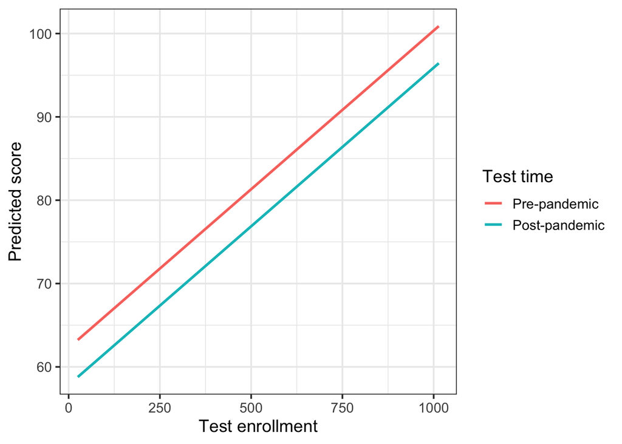

```r
lm(score ~ enrollment + post, df) %>%
margins(at = list(post = c("0", "1"))) %>%
  ggplot(aes(x= enrollment, y = fitted, color = as.factor(post))) +
  geom_smooth(method = 'lm', se = F) +
  labs( y = "Predicted score",
        x = "Test enrollment",
        color = "Test time") +
  scale_color_discrete(name = "Test time",
                       breaks = c("0", "1"),
                       labels = c("Pre-pandemic", "Post-pandemic")) +
  theme_bw(base_size = 14)
```

There are also some continuous variables in the data, if we want to add them as covariates to our model, we have to valuate potential multicollinearity beforehand:

```r
datasummary_correlation(df,
                        fmt = 3,
                        notes = "Notes: cells report Pearson correlation coefficients.")
```

|  | enrollment | frpl | asian | black | hisp | white | score |
| --- | --- | --- | --- | --- | --- | --- | --- |
| enrollment | 1 | . | . | . | . | . | . |
| frpl | −.213 | 1 | . | . | . | . | . |
| asian | .015 | −.028 | 1 | . | . | . | . |
| black | −.285 | .237 | −.053 | 1 | . | . | . |
| hisp | .230 | .129 | −.071 | −.219 | 1 | . | . |
| white | −.228 | −.217 | −.061 | −.130 | −.587 | 1 | . |
| score | .170 | −.178 | .064 | −.218 | .032 | .013 | 1 |

Notes: cells report Pearson correlation coefficients.

Did any variables concern you?

Subjective decision: adding post, grade, and remaining continuous variables (denoted by SCHCHAR) to the model

Here, y = score, x = enrollment

Null: there is no relationship between ORF score and test enrollment, after accounting for post-pandemic, grade-level, and a vector of school characteristics (i.e., proportion of students receiving free or reduced school lunch, asian students, black students, hispanic students, and white students), on average in the population.

Estimation equation:
$$SCORE = \beta_0 +
\beta_1 * ENROLLMENT + \beta_2 * POST + \beta_3 * GRADE + \beta_4 *
SCHCHAR + \epsilon$$

```r
m5 <- lm(score ~ enrollment + factor(post) + factor(grade) + frpl + asian + black + hisp + white, df)

modelsummary(list(m1, m2, m3, m4, m5),
             stars = TRUE,
             gof_omit = "Adj.|Log.Lik.|AIC|BIC")
```

|  | Model 1 | Model 2 | Model 3 | Model 4 | Model 5 |
| --- | --- | --- | --- | --- | --- |
| (Intercept) | 60.056*** | 75.125*** | 62.344*** | 27.406*** | 37.962*** |
|  | (0.569) | (0.367) | (0.492) | (0.279) | (0.739) |
| enrollment | 0.038*** |  |  |  | −0.0009 |
|  | (0.002) |  |  |  | (0.0009) |
| post1 |  | −4.450*** |  |  |  |
|  |  | (0.518) |  |  |  |
| factor(wave)2 |  |  | 25.562*** |  |  |
|  |  |  | (0.696) |  |  |
| factor(wave)3 |  |  | −2.791*** |  |  |
|  |  |  | (0.696) |  |  |
| factor(wave)4 |  |  | 19.454*** |  |  |
|  |  |  | (0.696) |  |  |
| factor(grade)2 |  |  |  | 38.987*** | 38.975*** |
|  |  |  |  | (0.400) | (0.380) |
| factor(grade)3 |  |  |  | 60.437*** | 59.842*** |
|  |  |  |  | (0.435) | (0.416) |
| factor(grade)4 |  |  |  | 82.174*** | 81.874*** |
|  |  |  |  | (0.461) | (0.445) |
| factor(grade)5 |  |  |  | 82.961*** | 82.930*** |
|  |  |  |  | (0.474) | (0.458) |
| factor(post)1 |  |  |  |  | −4.450*** |
|  |  |  |  |  | (0.273) |
| frpl |  |  |  |  | −1.437*** |
|  |  |  |  |  | (0.158) |
| asian |  |  |  |  | 27.725*** |
|  |  |  |  |  | (1.649) |
| black |  |  |  |  | −16.672*** |
|  |  |  |  |  | (0.616) |
| hisp |  |  |  |  | −11.398*** |
|  |  |  |  |  | (0.527) |
| white |  |  |  |  | 0.227 |
|  |  |  |  |  | (0.546) |
| Num.Obs. | 21584 | 21584 | 21584 | 21584 | 21584 |
| R2 | 0.029 | 0.003 | 0.102 | 0.693 | 0.725 |
| F | 638.837 | 73.686 | 817.703 | 12174.983 | 5161.238 |
| RMSE | 37.59 | 38.08 | 36.14 | 21.13 | 20.01 |

+ p < 0.1, * p < 0.05, ** p < 0.01, *** p < 0.001

ANCOVA results:

```r
anova(m5)
```

```
## Analysis of Variance Table
##
## Response: score
##                  Df   Sum Sq Mean Sq    F value Pr(>F)
## enrollment        1   902686  902686  2252.3941 <2e-16 ***
## factor(post)      1   106837  106837   266.5802 <2e-16 ***
## factor(grade)     4 20859023 5214756 13011.9314 <2e-16 ***
## frpl              1   181926  181926   453.9434 <2e-16 ***
## asian             1   168694  168694   420.9272 <2e-16 ***
## black             1   231319  231319   577.1914 <2e-16 ***
## hisp              1   302451  302451   754.6796 <2e-16 ***
## white             1       69      69     0.1725 0.6779
## Residuals     21572  8645351     401
## ---
## Signif. codes:  0 '***' 0.001 '**' 0.01 '*' 0.05 '.' 0.1 ' ' 1
```

Review [the lecture slides](https://daviddliebowitz.github.io/EDUC643_23W/slides/EDUC643_10_categorical.html#131) to accurately interpret your ANCOVA test results.

Additional notes: I recently came across [this blog](https://mlu-explain.github.io/linear-regression/) that looks to me like a neat, quick reference of multiple regression. Hope you find it helpful. The lecture slides/video recordings are of course still your best resources.